# Assignment 3.2

Manish Shah

2023-05-08

```r
library(tidyverse)
library(igraph)
```

## 1. Load the attached “termDocMatrix.rdata” file in R/R studio

```r
load("D:\\R programming runs\\Assisgnments\\Assignment 3\\Manish Shah - termDocMatrix.rdata")
```

## 2. Check the structure of this data and comment on it carefully

```r
str(termDocMatrix)
```

```
##  num [1:21, 1:154] 0 0 0 0 1 0 0 0 0 0 ...
##  - attr(*, "dimnames")=List of 2
##   ..$ Terms: chr [1:21] "analysis" "applications" "code" "computing" ...
##   ..$ Docs : chr [1:154] "1" "2" "3" "4" ...
```

It is a term document matrix with Terms as rows & Values(Docs) as columns where 0,1 & 2 values are stored

## 3. Inspect the first 10 rows and first 10 columns of this data using sub-setting

```r
termDocMatrix[1:10, 1:10]
```

```
##               Docs
## Terms          1 2 3 4 5 6 7 8 9 10
##   analysis     0 0 0 0 0 0 0 0 0  0
##   applications 0 0 0 0 0 0 0 0 0  0
##   code         0 0 0 0 0 0 0 0 0  0
##   computing    0 0 1 1 0 1 1 1 1  1
##   data         1 1 0 0 2 0 0 0 0  0
##   examples     0 0 0 0 0 0 0 0 0  0
##   introduction 0 0 0 0 0 0 0 0 0  0
##   mining       0 0 0 0 0 0 0 0 0  0
##   network      0 0 0 0 0 0 0 0 0  0
##   package      0 0 0 1 1 0 0 0 0  0
```

## 4. Convert the loaded termDocMatrix data to as matrix with appropriate R code

```r
term_matrix <- as.matrix(termDocMatrix)
```

## 5. Change this matrix to a Boolean matrix with same name (Hint: [termDocMatrix >=1] < 1)

```r
term_matrix[term_matrix >= 1] <- 1
```

## 6. Transform this matrix to a term-term adjacency matrix as termMatrix object (Hint: Use %*% and ## t(termDocMatrix)

```r
term_adj_matrix <- term_matrix %*% t(term_matrix)
```

## 7. Inspect the first 10 rows and first 10 columns of this matrix using sub-setting

```r
term_adj_matrix[1:10, 1:10]
```

```
##               Terms
## Terms          analysis applications code computing data examples introduction
##   analysis           23            0    1         0    4        4            2
##   applications        0            9    0         0    7        0            0
##   code                1            0    9         0    1        6            0
##   computing           0            0    0        10    1        0            0
##   data                4            7    1         1   53        5            2
##   examples            4            0    6         0    5       17            2
##   introduction        2            0    0         0    2        2           10
##   mining              4            6    3         1   34        5            2
##   network            12            0    1         0    0        2            2
##   package             2            1    0         2    7        2            0
##               Terms
## Terms          mining network package
##   analysis          4      12       2
##   applications      6       0       1
##   code              3       1       0
##   computing         1       0       2
##   data             34       0       7
##   examples          5       2       2
##   introduction      2       2       0
##   mining           47       1       5
##   network           1      17       1
##   package           5       1      21
```

## 8. Define a graph object g of termMatrix using graph.adjacency function of “igraph” package with weighted=T ## and mode=“undirected” arguments in the function

```r
g <- graph.adjacency(term_adj_matrix, mode = "undirected", weighted = T)
```

## 9. Remove loops of g using simplify function

```r
g <- simplify(g, remove.multiple = TRUE, remove.loops = TRUE)
```

## 10. Set vertices labels with names of g

```r
V(g)$label <- V(g)$name
```

## 11. Set degree with degree of g

```r
V(g)$degree <- degree(g)
```

## 12. Find degree of g for ’all”, “in” and “out” modes and interpret them carefully

```r
degree_all <- degree(g, mode = "all")
degree_all
```

```
##     analysis applications         code    computing         data     examples
##           17            6            9            9           18           14
## introduction       mining      network      package     parallel    positions
##           12           20           14           13            8            7
## postdoctoral            r     research       series       slides       social
##            8           17            9           11           15           11
##         time     tutorial        users
##           11           16           15
```

```r
degree(g, mode = "in")
```

```
##     analysis applications         code    computing         data     examples
##           17            6            9            9           18           14
## introduction       mining      network      package     parallel    positions
##           12           20           14           13            8            7
## postdoctoral            r     research       series       slides       social
##            8           17            9           11           15           11
##         time     tutorial        users
##           11           16           15
```

```r
degree(g, mode = "out")
```

```
##     analysis applications         code    computing         data     examples
##           17            6            9            9           18           14
## introduction       mining      network      package     parallel    positions
##           12           20           14           13            8            7
## postdoctoral            r     research       series       slides       social
##            8           17            9           11           15           11
##         time     tutorial        users
##           11           16           15
```

Degree means the arrow in & out from a node. From all degree we can observe that all terms has degree > 5 where the minimum degree is of **applications** i.e. 6 and maximum degree is of **mining** i.e. 20.  
Similarly, degree-in means the number of arrows pointing towards it whereas degree-out means the number of arrows pointing from it.  
The degree is same for all modes because it is *undirected.*

## 13. Find diameter of g and interpret it carefully

```r
diameter(g)
```

```
## [1] 5
```

The diameter means the longest shortest path between any two nodes. So, in this graph we have diameter of 5.

## 14. Find edge density of g and interpret it carefully

```r
edge_density(g)
```

```
## [1] 0.6190476
```

## 15. Find reciprocity of g and interpret it carefully

```r
reciprocity(g)
```

```
## [1] 1
```

## 16. Find closeness of g and interpret it carefully

```r
closeness(g)
```

```
##     analysis applications         code    computing         data     examples
##   0.01960784   0.01818182   0.02272727   0.02500000   0.02222222   0.02040816
## introduction       mining      network      package     parallel    positions
##   0.02380952   0.02380952   0.02500000   0.02222222   0.02380952   0.01694915
## postdoctoral            r     research       series       slides       social
##   0.01785714   0.01282051   0.01960784   0.02040816   0.02564103   0.02127660
##         time     tutorial        users
##   0.02040816   0.02631579   0.01886792
```

## 17. Find betweenness of g and interpret it carefully

```r
betweenness(g)
```

```
##     analysis applications         code    computing         data     examples
##    3.9939394    4.1873737   13.6893939   22.3222222    9.5303030    0.5111111
## introduction       mining      network      package     parallel    positions
##   17.2323232   20.6666667   17.8202020   12.0050505    7.3722222    0.2500000
## postdoctoral            r     research       series       slides       social
##    0.0000000    0.0000000    8.6247475    1.6333333   22.5272727    5.6242424
##         time     tutorial        users
##    1.6333333   24.3863636    4.6151515
```

Betweenness means how many times a node lies between shortest path of two nodes.

## 18. Plot histogram of node degree and interpret it carefully

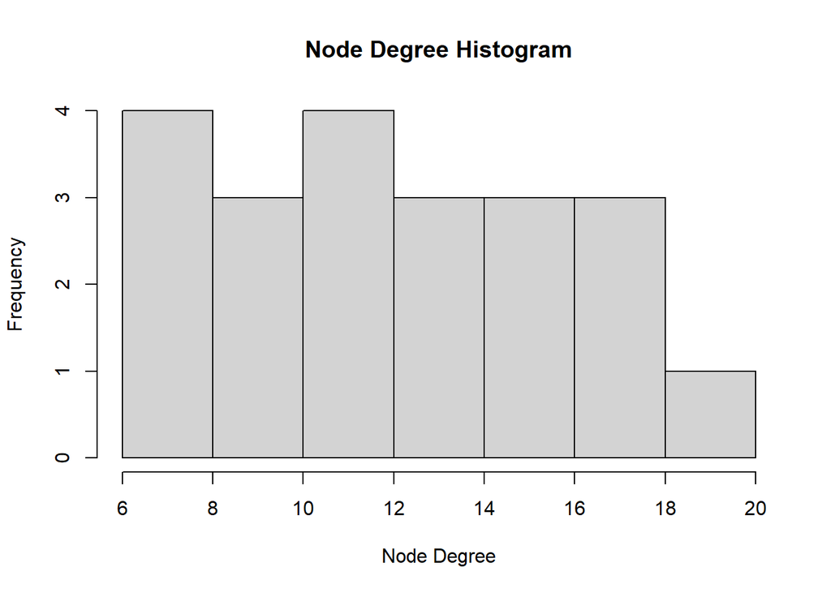

```r
hist(degree_all, main = "Node Degree Histogram", xlab = "Node Degree")
```

The node degree ranges from 6 to 20 where 6-8 & 10-12 has high degree to vertex & 18-20 is lowest i.e. 1 vertex.

## 19. Set seed as per your class roll number

```r
set.seed(16)
```

## 20. plot g with vertex.size of degree*0.4 and interpret it carefully

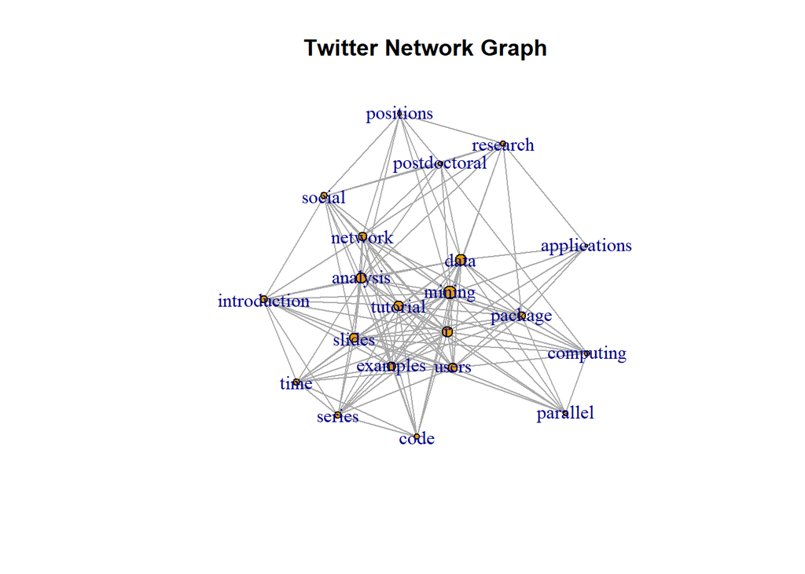

```r
plot(g, vertex.size = degree_all*0.4, main="Twitter Network Graph")
```

From the graph, we can observe that highest degree nodes are in center i.e. *mining, data, tutorial, analysis, etc* have high degree.

## 21. plot g with fruchterman.reingold layout and interpret it carefully

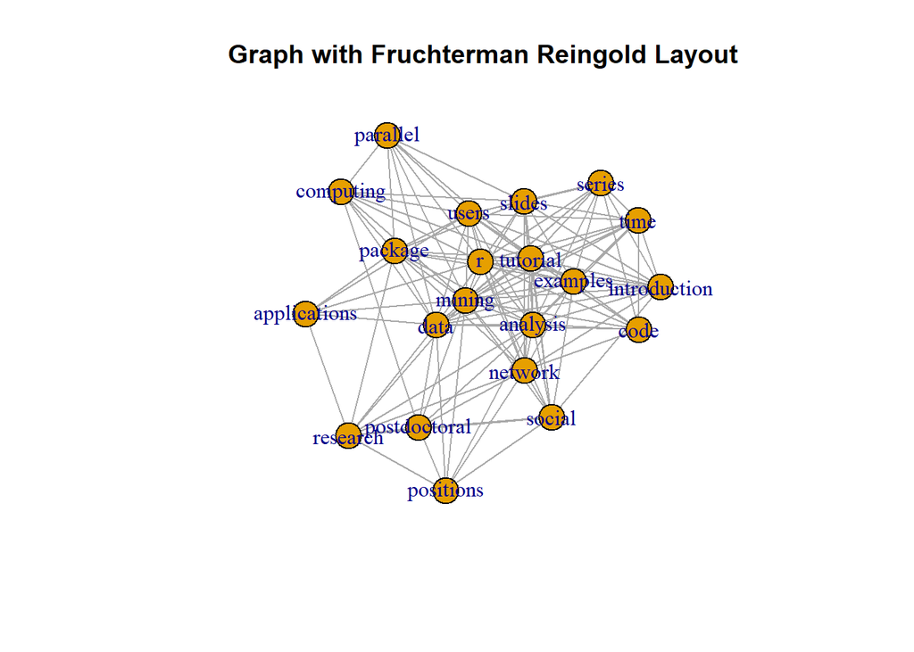

```r
plot(g, layout=layout.fruchterman.reingold, main="Graph with Fruchterman Reingold Layout")
```

In this graph also we can observe nodes with high degree are in center & lowest are outside.

## 22. plot g with kamada.kawai layout and interpret it carefully

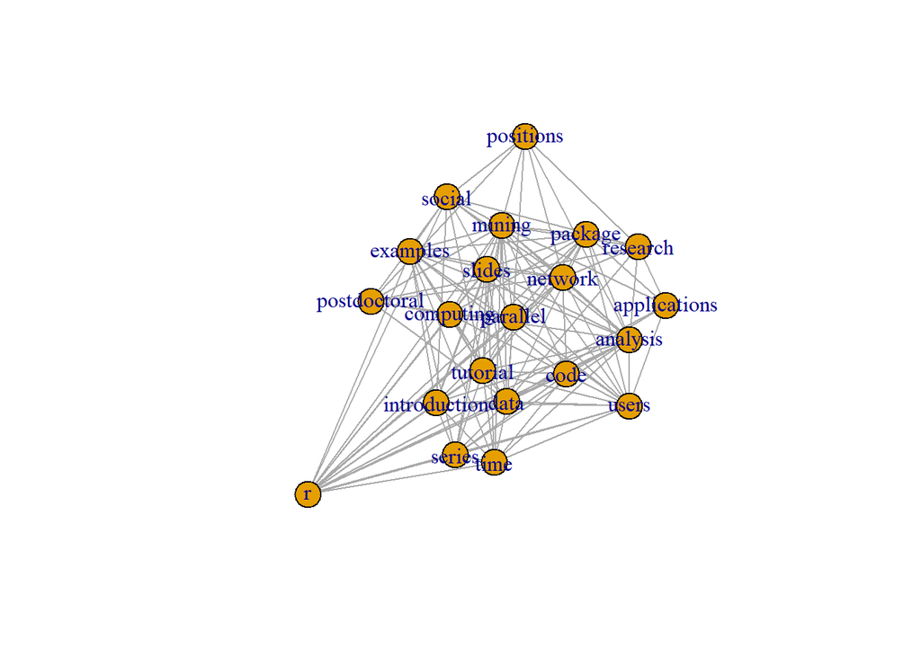

```r
plot(g, layout=layout.kamada.kawai)
```

## 23. plot hub and authority of g and interpret them carefully

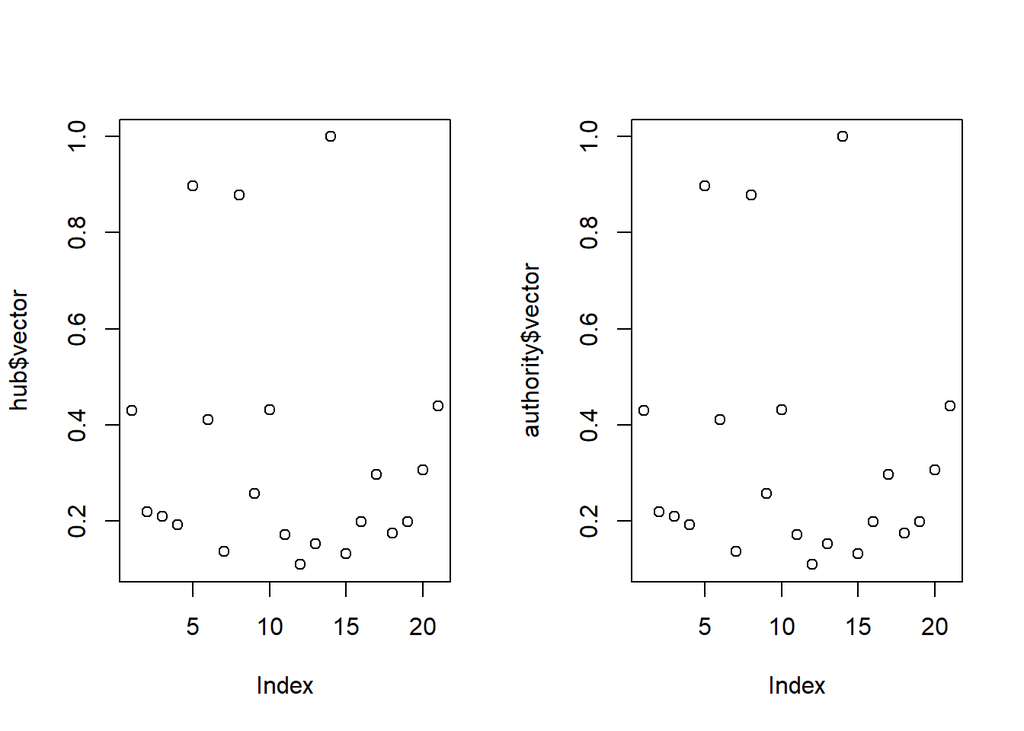

```r
par(mfrow=c(1,2))
hub <- hub_score(g)
authority <- authority.score(g)

plot(hub$vector)
plot(authority$vector)
```

```r
par(mfrow=c(1,1))
```

Hubs are the outgoing edges & authorities are the incoming egdes. Since the graph is undirected, so the plot is same.

## 24. Plot community cluster of g and interpret it carefully

Detect communities & then plot

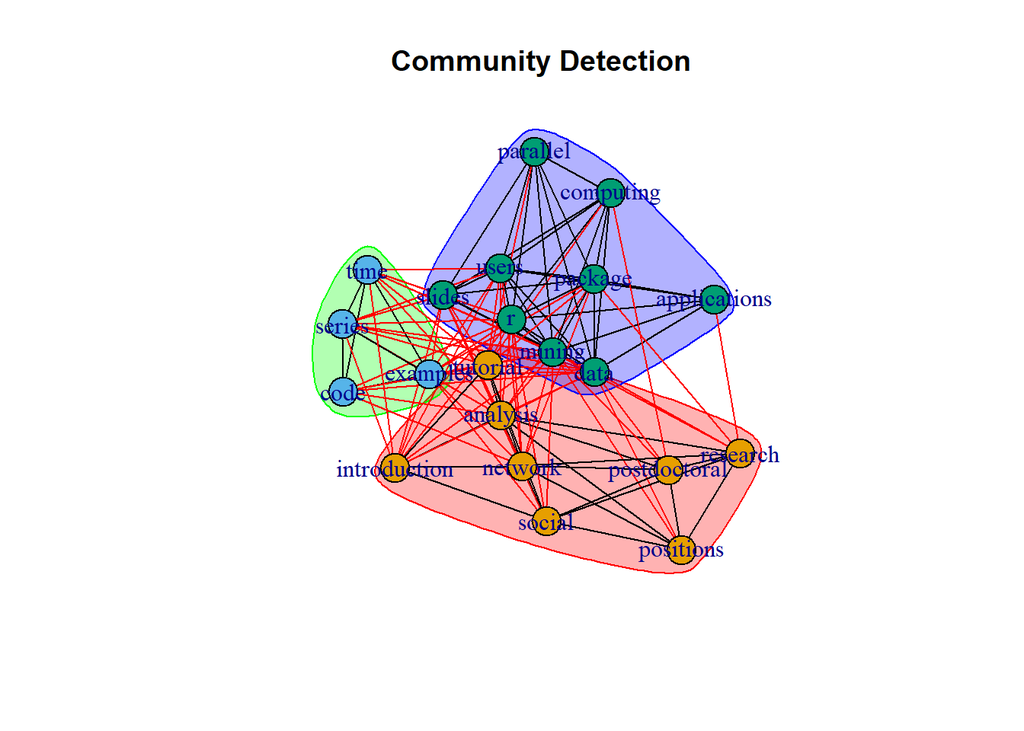

```r
fc <- cluster_fast_greedy(g)
plot(fc, g, vertex.color = fc$membership, main = 'Community Detection')
```

## 25. Write a summary of SNA for the twitter data

Each nodes are the terms & each edges connected to nodes means the terms are occurred frequently simultaneously. The most used terms in given termdocumentmatrix is *data* & *mining*.